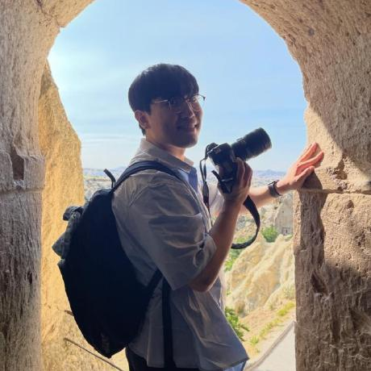

# Yonghun Suh

*Enabling HPC in Geography*

Email [ORCID](https://orcid.org/0009-0003-6800-2731) [Github](https://github.com/YONGHUNI) [CV](https://yonghuni.github.io/curriculum-vitae/CV.pdf)

# About Me

I am pursuing a Ph.D. in Geography at the [**University of Georgia**](https://www.uga.edu/), advised by [Dr. Weiming Hu](https://weiming.uga.edu/) in the GAIM Lab. My research interests include **GIScience, geospatial AI, and remote sensing**, with a particular interest in applying **high-performance computing (HPC)** to large-scale geospatial data analysis.

Before joining UGA, I worked as a research intern in the [Data Science for Humanity Group](https://www.mpi-sp.org/cha) at the [**Max Planck Institute for Security and Privacy**](https://www.mpi-sp.org/), where I applied satellite remote sensing to environmental and humanitarian research. I earned my M.A. in Geography from [**Seoul National University**](https://www.snu.ac.kr/), where I worked on spatial modeling projects including [building-scale population estimation](https://journal.cartography.or.kr/articles/article/Ad7w/) and [landslide susceptibility analysis](https://journal.cartography.or.kr/articles/article/GmX8/).

# Education

## University of Georgia

- Ph.D. in Geography (in progress)
  - Advisor: [Dr. Weiming Hu](https://weiming.uga.edu/) (GAIM Lab)
  - **Graduate Research Assistant:** Developing reproducible HPC workflows for AI-based weather forecasting, including GraphCast, to support subseasonal-to-seasonal atmospheric river forecasting research.

## Seoul National University

#### Seoul, South Korea | Sept 2021 – Feb 2024

- M.A. in Geography
  - Thesis: Real-time Landslide Susceptibility Monitoring Using Spatio-temporal High-resolution Active Remote Sensing Data: An Interpretable Machine Learning Approach ([available in Korean](https://s-space.snu.ac.kr/handle/10371/210790))
  - Advised by [Dr. Gunhak Lee](https://geog.snu.ac.kr/bbs/board.php?tbl=bbs13&mode=VIEW&num=11&category=&findType=&findWord=&sort1=&sort2=&it_id=&shop_flag=&mobile_flag=&language=EN&page=1)

## Kongju National University

#### South Chungcheong Province, South Korea | Mar 2015 – Aug 2021

- B.A. in Geography
- B.Sc. in Atmospheric Science

# Research Highlights

## Mapping Reduced Accessibility to WASH Facilities in Rohingya Refugee Camps with Sub-Meter Imagery (**under review**)

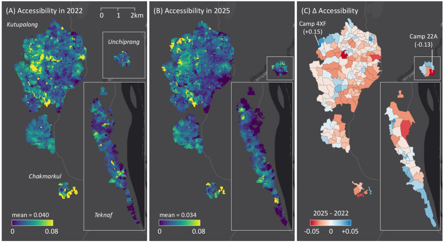

Accessibility in 2022 (A), 2025 (B), and change (C)

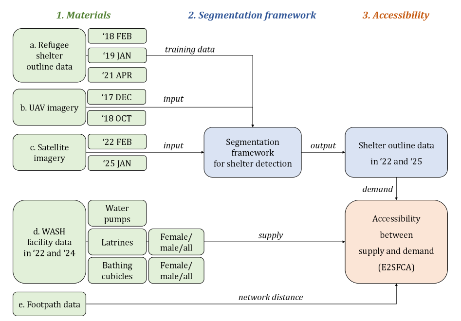

Method overview

- This study assesses changes in spatial accessibility to WASH (Water, Sanitation, and Hygiene) facilities in Rohingya refugee camps using a 2SFCA approach with shelter detection from sub-meter imagery via a semi-supervised segmentation model, addressing challenges from dense and heterogeneous camp structures.
- Accessibility declined over time, with the lack of gender-segregated facilities revealing persistent accessibility inequality.
- Links to the [Preprint](https://arxiv.org/abs/2511.07231) & [Source Code](https://github.com/DS4H-GIS/Refugee_WASH_Accessibility)

## From Data to Dissemination: Creating Dashboards for Buffalo African-American Community-based Participatory Air Monitoring

[figure not shown]

Breathe Buffalo: UB Air Quality Monitoring Dashboard

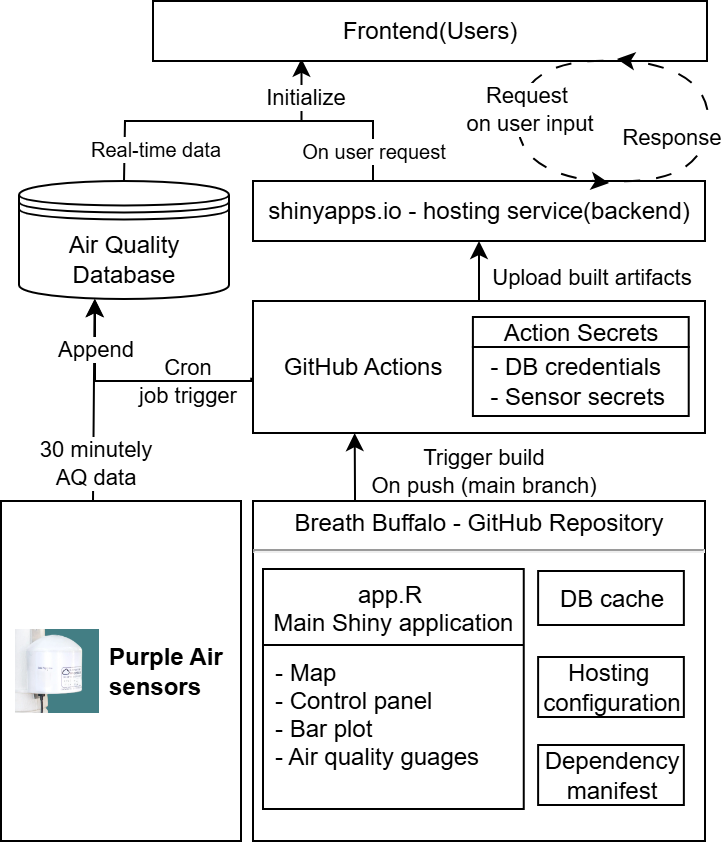

Architecture Overview

- [This project](https://ubairqualitystudy.github.io/EPA-Website/index.html) deployed 30 low-cost air sensors across East Buffalo to capture local PM2.5 data, revealing pollution patterns overlooked by official monitors.
- A community-designed dashboard improved real-time access to air quality data, supporting environmental awareness and public health equity.
- The findings were presented at the *Joint Annual Meeting of the International Society of Exposure Science and the International Society for Environmental Epidemiology 2025 (ISES-ISEE 2025)*.
- Links to the [Poster](https://github.com/YONGHUNI/Breathe-Buffalo/blob/main/Poster/Creating_Dashboards_for_Buffalo_African_American_Community_based_Participatory_Air_Monitoring_final.pdf?raw=true) & [Source Code](https://github.com/YONGHUNI/Breathe-Buffalo)

## Predicting Landslide Susceptibility Using High-resolution Active Remote Sensing Data: An Interpretable Machine Learning Approach

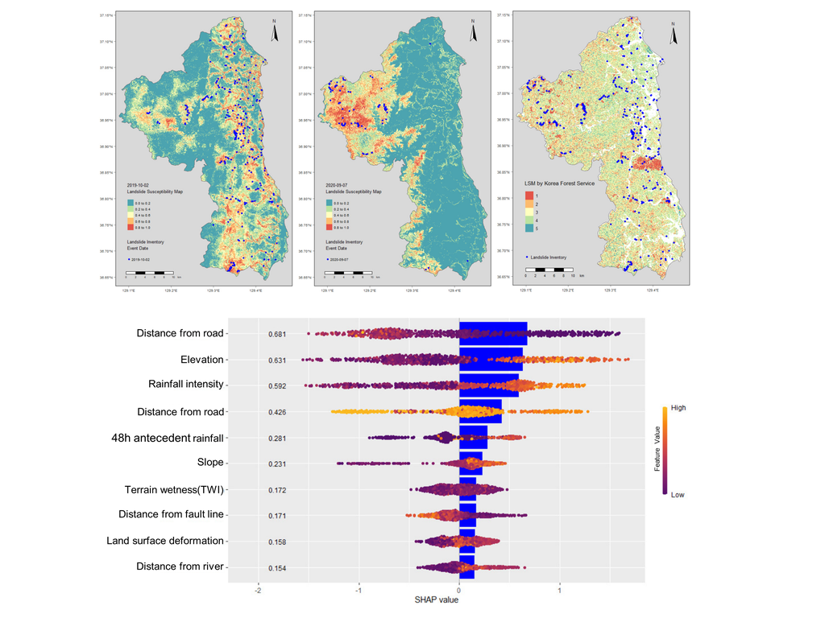

- This study presents a machine learning model to predict landslide susceptibility using Interferometric SAR displacement data and Hybrid Surface Rainfall estimates, emphasizing the role of active remote sensing.
- The findings highlight the potential of using remote sensing data for landslide susceptibility assessment, offering valuable insights for disaster preparedness and mitigation strategies.
- [Published](https://journal.cartography.or.kr/articles/article/GmX8/) in *Journal of the Korean Cartographic Association* with [Dr. Gunhak Lee](https://geog.snu.ac.kr/bbs/board.php?tbl=bbs13&mode=VIEW&num=11&category=&findType=&findWord=&sort1=&sort2=&it_id=&shop_flag=&mobile_flag=&language=EN&page=1).

## Delayed effects of air pollution on public bike-sharing system use in Seoul, South Korea: A time series analysis

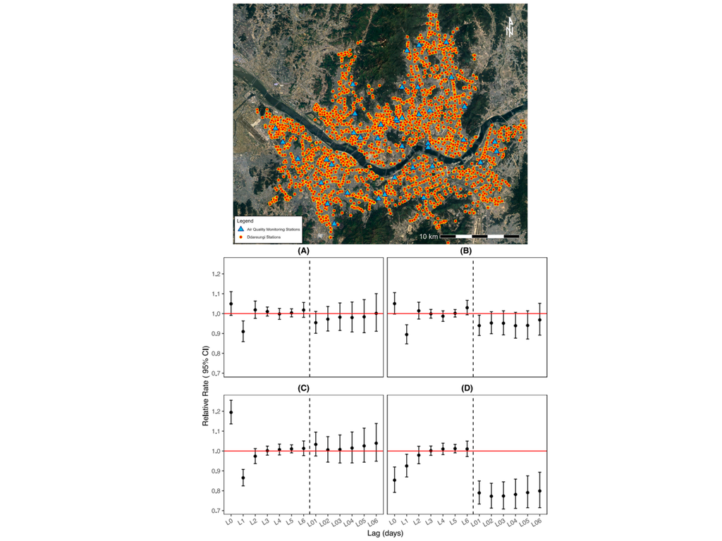

## Estimation of the de Facto Population at the Building Scale Using a Dasymetric Mapping Method Based on GWR

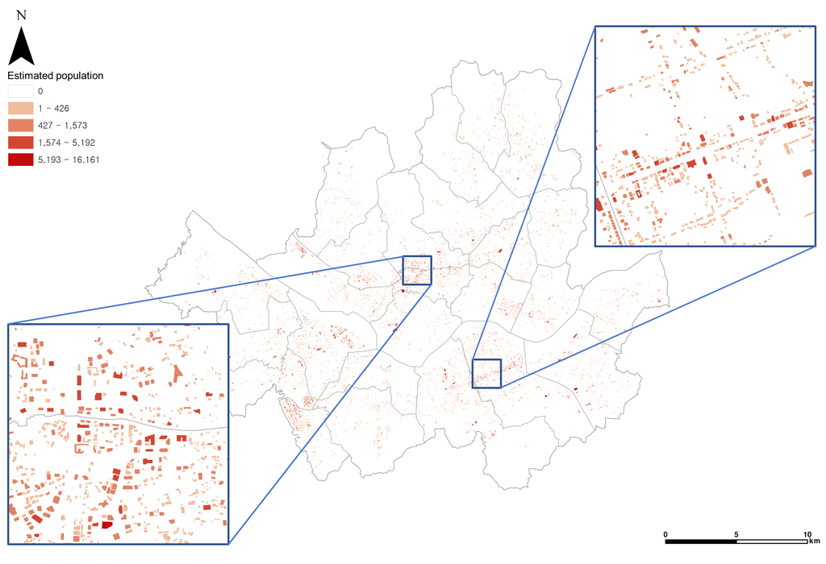

- This study proposes a method using geographically weighted regression(GWR) and dasymetric mapping to estimate fine-scale population in buildings, addressing the challenges of COVID-19 transmission in urban areas.
- By utilizing building usage and floor area as auxiliary data, it provides detailed population distribution estimates for Seoul, which can inform effective pandemic response strategies.
- [Published](https://journal.cartography.or.kr/articles/article/Ad7w/#Abstract) in *Journal of the Korean Cartographic Association* with [Dr. Gunhak Lee](https://geog.snu.ac.kr/bbs/board.php?tbl=bbs13&mode=VIEW&num=11&category=&findType=&findWord=&sort1=&sort2=&it_id=&shop_flag=&mobile_flag=&language=EN&page=1).

## Accessibility Analysis of Public Cooling Shelters in Seoul Considering Local Temperature: Focusing on the Elderly Population

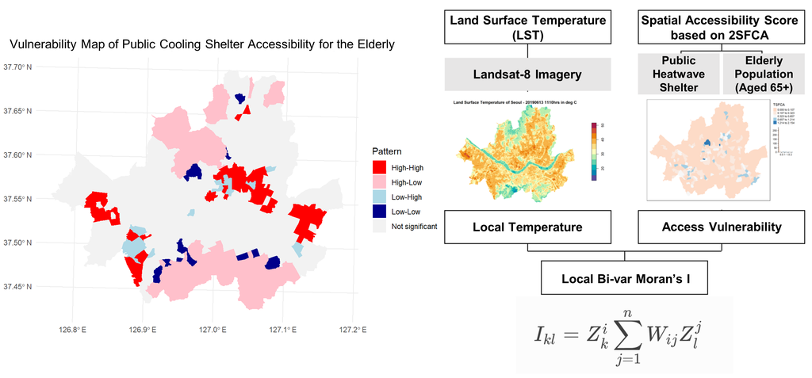

- This study aimed to identify vulnerable areas and inform heatwave policy decisions.
- It examined vulnerability using local Bi-var Moran’s I, analyzing the spatial accessibility of heatwave shelters for the elderly and temperature variations in Seoul.
- The findings were presented at the *2022 Annual Conference of the Korean Geographical Society*.

# CV

You can either view or [download](https://yonghuni.github.io/curriculum-vitae/CV.pdf) my CV here!

[interactive chart not shown]